# Island Biogeography Analysis

Autumn Pauly and Asher Panikian

2024-03-14

## 0.1 Loading the Data

First, we’ll want to load the appropriate packages and data for the analysis of this dataset.

```r
library(tidyverse)
```

```r
knitr::opts_chunk$set(echo = TRUE)
library(RColorBrewer)
library(stringr)
#install.packages("plotly")
#library(plotly)
#install.packages("gapminder")
#library(gapminder)
```

## 0.2 Analysis

### 0.2.1 Otter Body Length

First, we’ll want to factor the variables `AREA` and `REGION` to be spatially representative of where the locations within the dataset are.

```r
#factoring locations
seot$AREA <- factor(seot$AREA, levels = c("rat_islands", "delarof_islands", "andreanof_islands", "eastern_prince_william_sound", "western_prince_william_sound"))

seot$REGION <- factor(seot$REGION, levels = c("west_aleutians", "east_aleutians", "alaskan_peninsula", "southeast_alaska", "prince_william_sound"))
```

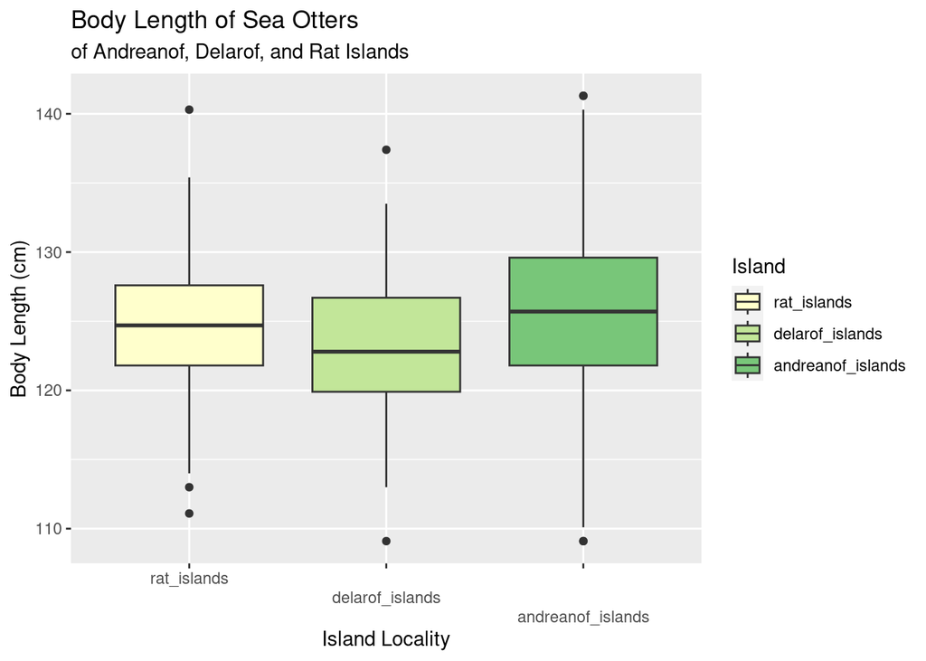

```r
#boxplot of lengths by area not including prince william sound
seot %>%
  filter(AREA == "andreanof_islands"|AREA == "rat_islands"|AREA == "delarof_islands"| AREA == "afognak_island") %>%
  filter(FINAL_AGE > 4) %>%
  filter(SEX == "F") %>%
  ggplot(mapping = aes(x = AREA, y = true_standard_lgth, fill = AREA)) +
  geom_boxplot() +
  scale_fill_manual(values = c("#ffffcc", "#c2e699", "#78c679","#31a354","#006837")) +
  scale_x_discrete(guide = guide_axis(n.dodge = 3)) +
  labs(title = "Body Length of Sea Otters",
       subtitle = "of Andreanof, Delarof, and Rat Islands",
       x = "Island Locality",
       y = "Body Length (cm)",
       fill = "Island")
```

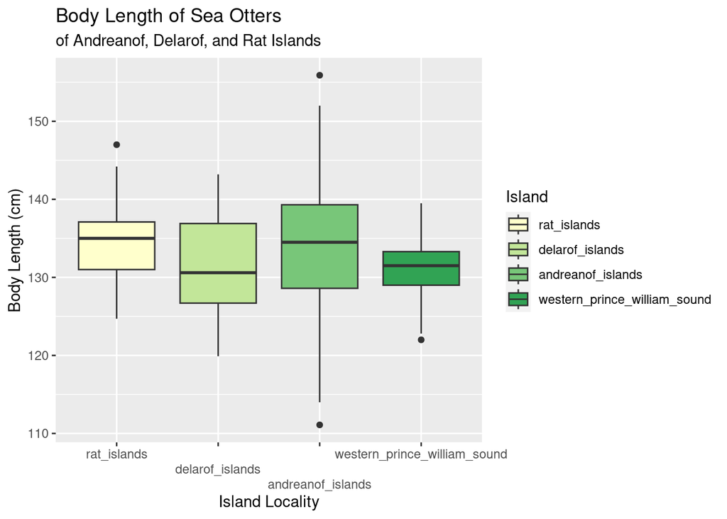

```r
#boxplots of lengths including prince william sound
seot %>%
  filter(AREA == "andreanof_islands"|AREA == "rat_islands"|AREA == "delarof_islands"| AREA == "western_prince_william_sound") %>%
  filter(FINAL_AGE > 4) %>%
    filter(SEX == "M") %>%
  ggplot(mapping = aes(x = AREA, y = true_standard_lgth, fill = AREA)) +
  geom_boxplot() +
  scale_fill_manual(values = c("#ffffcc", "#c2e699", "#78c679","#31a354","#006837")) +
  scale_x_discrete(guide = guide_axis(n.dodge = 3)) +
  labs(title = "Body Length of Sea Otters",
       subtitle = "of Andreanof, Delarof, and Rat Islands",
       x = "Island Locality",
       y = "Body Length (cm)",
       fill = "Island")
```

```r
#statistical analysis of difference - Welch's ANOVA
seot_close <- seot %>%
  filter(AREA == "andreanof_islands"|AREA == "rat_islands"|AREA == "delarof_islands"|AREA == "western_prince_william_sound")

seot_aov <- aov(true_standard_lgth ~ AREA, data = seot_close)
TukeyHSD(seot_aov)
```

```
##   Tukey multiple comparisons of means
##     95% family-wise confidence level
##
## Fit: aov(formula = true_standard_lgth ~ AREA, data = seot_close)
##
## $AREA
##                                                     diff        lwr        upr
## delarof_islands-rat_islands                    -0.927732 -4.1781441  2.3226801
## andreanof_islands-rat_islands                   2.942585  1.5240799  4.3610900
## western_prince_william_sound-rat_islands       -2.024451 -3.7289071 -0.3199953
## andreanof_islands-delarof_islands               3.870317  0.6552418  7.0853921
## western_prince_william_sound-delarof_islands   -1.096719 -4.4477969  2.2543585
## western_prince_william_sound-andreanof_islands -4.967036 -6.6030983 -3.3309739
##                                                    p adj
## delarof_islands-rat_islands                    0.8836010
## andreanof_islands-rat_islands                  0.0000006
## western_prince_william_sound-rat_islands       0.0122314
## andreanof_islands-delarof_islands              0.0107163
## western_prince_william_sound-delarof_islands   0.8348007
## western_prince_william_sound-andreanof_islands 0.0000000
```

#### 0.2.1.1 Linear Model

```r
# #now, let's create the linear model comparing final age to baculum length
#
# seot_body_model <- linear_reg() %>%
#   set_engine("lm") %>%
#   fit(true_standard_lgth ~ AREA + FINAL_AGE, data = seot_close)
#
# #let's tidy this model
# seot_body_model %>% tidy()
#
# #augmenting the baculum data
# seot_body_model_augment <- augment(seot_body_model$fit)
#
# ggplot(seot_body_model_augment, mapping = aes(x = .fitted, y = .resid, color = .resid)) +
#   geom_jitter(alpha = 0.75) +
#   scale_color_viridis_c() +
#   geom_smooth(color = "black") +
#   labs(x = "Predicted Age", y = "Residuals")
#
# #assessing the r-squared value
# glance(seot_body_model)$adj.r.squared
```

### 0.2.2 Otter Tail Length

```r
seot %>%
  filter(mean_tail_lgth > 0) %>%
  count(AREA) %>%
  arrange(desc(n))
```

```
##                           AREA   n
## 1                         <NA> 190
## 2 western_prince_william_sound 153
## 3                  rat_islands  35
## 4            andreanof_islands  24
```

```r
seot %>%
  filter(mean_tail_lgth > 0) %>%
  count(AREA) %>%
  arrange(desc(n))
```

```
##                           AREA   n
## 1                         <NA> 190
## 2 western_prince_william_sound 153
## 3                  rat_islands  35
## 4            andreanof_islands  24
```

#### 0.2.2.1 Creating Graphs

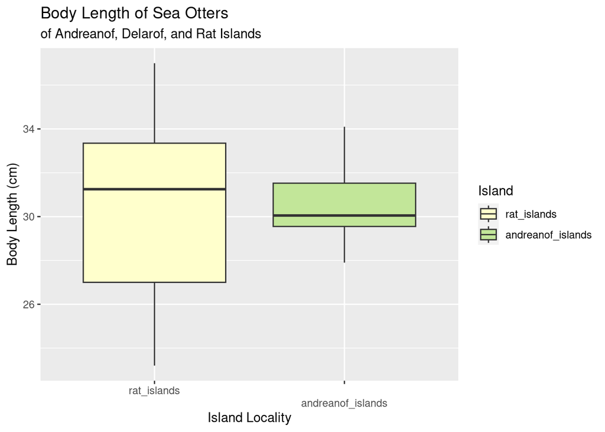

```r
#boxplot of tail lengths by area not including prince william sound
seot %>%
  filter(AREA == "rat_islands"|AREA == "andreanof_islands") %>%
  filter(SEX == "M") %>%
  ggplot(mapping = aes(x = AREA, y = mean_tail_lgth, fill = AREA)) +
  geom_boxplot() +
  scale_fill_manual(values = c("#ffffcc", "#c2e699", "#78c679","#31a354","#006837")) +
  scale_x_discrete(guide = guide_axis(n.dodge = 3)) +
  labs(title = "Body Length of Sea Otters",
       subtitle = "of Andreanof, Delarof, and Rat Islands",
       x = "Island Locality",
       y = "Body Length (cm)",
       fill = "Island")
```

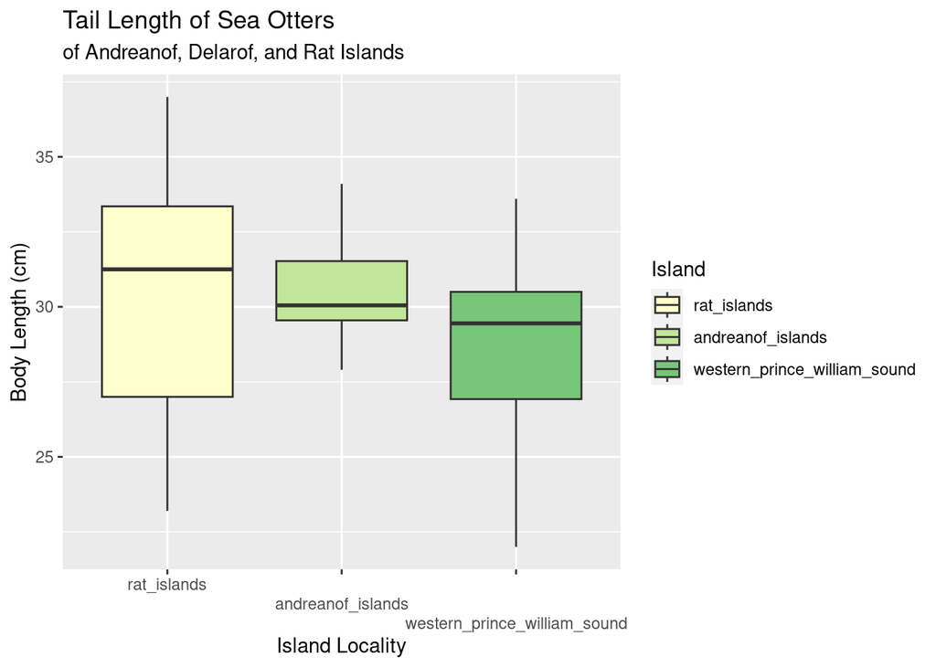

```r
#boxplots of tail lengths including prince william sound
seot %>%
  filter(AREA == "western_prince_william_sound"|AREA == "rat_islands"|AREA == "andreanof_islands") %>%
  filter(SEX == "M") %>%
  ggplot(mapping = aes(x = AREA, y = mean_tail_lgth, fill = AREA)) +
  geom_boxplot() +
  scale_fill_manual(values = c("#ffffcc", "#c2e699", "#78c679","#31a354","#006837")) +
  scale_x_discrete(guide = guide_axis(n.dodge = 3)) +
  labs(title = "Tail Length of Sea Otters",
       subtitle = "of Andreanof, Delarof, and Rat Islands",
       x = "Island Locality",
       y = "Body Length (cm)",
       fill = "Island")
```

#### 0.2.2.2 Statistical Analysis

```r
#statistical analysis of difference - Welch's ANOVA
seot_close <- seot %>%
  filter(AREA == "andreanof_islands"|AREA == "rat_islands"|AREA == "western_prince_william_sound")

seot_aov <- aov(mean_tail_lgth ~ AREA, data = seot_close)
TukeyHSD(seot_aov)
```

```
##   Tukey multiple comparisons of means
##     95% family-wise confidence level
##
## Fit: aov(formula = mean_tail_lgth ~ AREA, data = seot_close)
##
## $AREA
##                                                      diff        lwr
## andreanof_islands-rat_islands                   0.7182143 -0.9619996
## western_prince_william_sound-rat_islands       -0.6870962 -1.8749894
## western_prince_william_sound-andreanof_islands -1.4053105 -2.7972280
##                                                        upr     p adj
## andreanof_islands-rat_islands                   2.39842815 0.5719943
## western_prince_william_sound-rat_islands        0.50079701 0.3610025
## western_prince_william_sound-andreanof_islands -0.01339294 0.0472522
```

```r
#t-test for prince williams sound and andreanof islands
seot_close <- seot %>%
  filter(AREA == "andreanof_islands"|AREA == "western_prince_william_sound") %>%
  filter(SEX == "M")

t.test(mean_tail_lgth ~ AREA, data = seot_close)
```

```
##
##  Welch Two Sample t-test
##
## data:  mean_tail_lgth by AREA
## t = 2.6303, df = 27.297, p-value = 0.01386
## alternative hypothesis: true difference in means between group andreanof_islands and group western_prince_william_sound is not equal to 0
## 95 percent confidence interval:
##  0.3958817 3.1979780
## sample estimates:
##            mean in group andreanof_islands
##                                   30.49167
## mean in group western_prince_william_sound
##                                   28.69474
```

REPORT: The mean tail lenghts of the sea otters captured on the Rat Islands did not differ significantly from the otters captured on either the Andreanof Islands (Tukey Multiple Comparison of Means; p-value = 0.57) or Prince William Sound (Tukey Multiple Comparison of Means; p-value = 0.36). The tail lengths of the otters from the Andreanof Islands did differ significantly from those that were captured in Prince William Sound (Tukey Multiple Comparison of Means; p-value = 0.047).

#### 0.2.2.3 Linear Model

```r
# seot_close <- seot %>%
#   filter(AREA == "andreanof_islands"|AREA == "western_prince_william_sound") %>%
#   filter(SEX == "M")
#
# seot_close_model <- linear_reg() %>%
#   set_engine("lm") %>%
#   fit(mean_tail_lgth ~ AREA + FINAL_AGE, data = seot_close)
#
# #let's tidy this model
# seot_close_model %>% tidy()
#
# #augmenting the baculum data
# seot_close_model_augment <- augment(seot_close_model$fit)
#
# ggplot(seot_close_model_augment, mapping = aes(x = .fitted, y = .resid, color = .resid)) +
#   geom_jitter(alpha = 0.75) +
#   scale_color_viridis_c() +
#   geom_smooth(color = "black") +
#   labs(x = "Predicted Age", y = "Residuals")
#
# #assessing the r-squared value
# glance(seot_close_model)$adj.r.squared
```

### 0.2.3 Otter Weight

```r
seot %>%
  filter(WEIGHT > 0) %>%
  count(AREA) %>%
  arrange(desc(n))
```

```
##                           AREA    n
## 1            andreanof_islands 1583
## 2                  rat_islands 1251
## 3 western_prince_william_sound  776
## 4                         <NA>  510
## 5 eastern_prince_william_sound  207
## 6              delarof_islands  144
```

#### 0.2.3.1 Creating Graphs

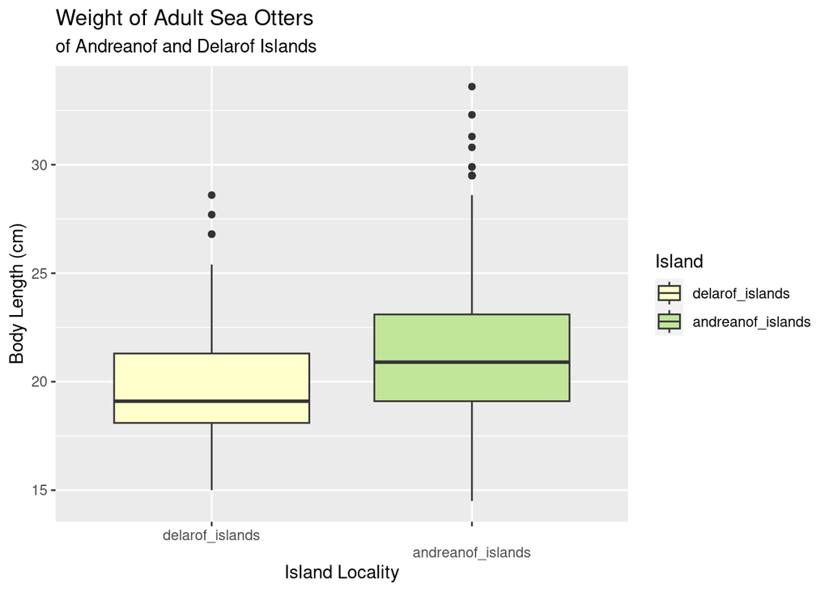

```r
#boxplot of tail lengths by area not including prince william sound
seot %>%
  filter(AREA == "delarof_islands"| AREA == "andreanof_islands") %>%
    filter(SEX == "F") %>%
  filter(FINAL_AGE > 4) %>%
  ggplot(mapping = aes(x = AREA, y = WEIGHT, fill = AREA)) +
  geom_boxplot() +
  scale_fill_manual(values = c("#ffffcc", "#c2e699", "#78c679","#31a354","#006837")) +
  scale_x_discrete(guide = guide_axis(n.dodge = 3)) +
  labs(title = "Weight of Adult Sea Otters",
       subtitle = "of Andreanof and Delarof Islands",
       x = "Island Locality",
       y = "Body Length (cm)",
       fill = "Island")
```

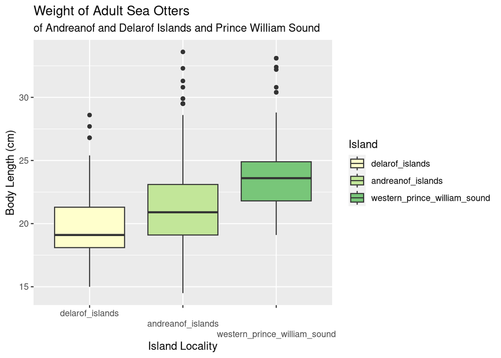

```r
#boxplots of tail lengths including prince william sound
seot %>%
  filter(AREA == "western_prince_william_sound"|AREA == "delarof_islands"| AREA == "andreanof_islands") %>%
  filter(SEX == "F") %>%
    filter(FINAL_AGE > 4) %>%
  ggplot(mapping = aes(x = AREA, y = WEIGHT, fill = AREA)) +
  geom_boxplot() +
  scale_fill_manual(values = c("#ffffcc", "#c2e699", "#78c679","#31a354","#006837")) +
  scale_x_discrete(guide = guide_axis(n.dodge = 3)) +
  labs(title = "Weight of Adult Sea Otters",
       subtitle = "of Andreanof and Delarof Islands and Prince William Sound",
       x = "Island Locality",
       y = "Body Length (cm)",
       fill = "Island")
```

#### 0.2.3.2 Statistical Analysis

```r
#statistical analysis of difference - t-test - delarof_islands and western_prince_william_sound
seot_close <- seot %>%
  filter(AREA == "delarof_islands"|AREA == "western_prince_william_sound") %>%
  filter(SEX == "F") %>%
  filter(FINAL_AGE > 4)

t.test(WEIGHT ~ AREA, data = seot_close)
```

```
##
##  Welch Two Sample t-test
##
## data:  WEIGHT by AREA
## t = -10.288, df = 109.2, p-value < 2.2e-16
## alternative hypothesis: true difference in means between group delarof_islands and group western_prince_william_sound is not equal to 0
## 95 percent confidence interval:
##  -4.528746 -3.065697
## sample estimates:
##              mean in group delarof_islands
##                                   19.76234
## mean in group western_prince_william_sound
##                                   23.55956
```

```r
#statistical analysis of difference - t-test - andreanof_islands and western_prince_william_sound
seot_close <- seot %>%
  filter(AREA == "andreanof_islands"|AREA == "western_prince_william_sound")%>%
  filter(SEX == "F") %>%
  filter(FINAL_AGE > 4)

t.test(WEIGHT ~ AREA, data = seot_close)
```

```
##
##  Welch Two Sample t-test
##
## data:  WEIGHT by AREA
## t = -11.554, df = 582.7, p-value < 2.2e-16
## alternative hypothesis: true difference in means between group andreanof_islands and group western_prince_william_sound is not equal to 0
## 95 percent confidence interval:
##  -2.570794 -1.823772
## sample estimates:
##            mean in group andreanof_islands
##                                   21.36228
## mean in group western_prince_william_sound
##                                   23.55956
```

```r
#statistical analysis of difference - t-test - delarof_islands and andreanof_islands
seot_close <- seot %>%
  filter(AREA == "delarof_islands"|AREA == "andreanof_islands")%>%
  filter(SEX == "F") %>%
  filter(FINAL_AGE > 4)

t.test(WEIGHT ~ AREA, data = seot_close)
```

```
##
##  Welch Two Sample t-test
##
## data:  WEIGHT by AREA
## t = -4.5091, df = 94.231, p-value = 1.873e-05
## alternative hypothesis: true difference in means between group delarof_islands and group andreanof_islands is not equal to 0
## 95 percent confidence interval:
##  -2.304429 -0.895447
## sample estimates:
##   mean in group delarof_islands mean in group andreanof_islands
##                        19.76234                        21.36228
```

REPORT: The weight of adult female sea otters were significantly heavier in western Prince William Sound than the weights of the adult female sea otters on the Delarof Islands (Welch Two Sample t-test; t = -10.288, df = 109.2, p-value < 2.2e-16). The average weight of an adult female from Prince William Sound was 23.56 kg. The average weight of an adult female from the Delarof Islands was 19.76 kg.

REPORT: The weight of adult female sea otters were significantly heavier in western Prince William Sound than the weights of the adult female sea otters on the Andreanof Islands (Welch Two Sample t-test; t = -11.554, df = 582.7, p-value < 2.2e-16). The average weight of an adult female from Prince William Sound was 23.56 kg. The average weight of an adult female from the Andreanof Islands was 21.36 kg.

REPORT: The weight of adult female sea otters were significantly heavier on the Andreanof Islands than the weights of the adult female sea otters on the Delarof Islands (Welch Two Sample t-test; t = -4.5091, df = 94.231, p-value = 1.873e-05). The average weight of an adult female from Delarof Islands was 19.76 kg. The average weight of an adult female from the Andreanof Islands was 21.36 kg.

#### 0.2.3.3 Linear Model

```r
# seot_close <- seot %>%
#   filter(AREA == "delarof_islands"|AREA == "western_prince_william_sound"|AREA == "andreanof_islands") %>%
#   filter(SEX == "F") %>%
#   filter(FINAL_AGE > 4)
#
# seot_weight_model <- linear_reg() %>%
#   set_engine("lm") %>%
#   fit(WEIGHT ~ AREA + AGE_CATEGORY, data = seot_close)
#
# #let's tidy this model
# seot_close_model %>% tidy()
#
# #augmenting the baculum data
# seot_weight_model_augment <- augment(seot_weight_model$fit)
#
# ggplot(seot_weight_model_augment, mapping = aes(x = .fitted, y = .resid, color = .resid)) +
#   geom_jitter(alpha = 0.75) +
#   scale_color_viridis_c() +
#   geom_smooth(color = "black") +
#   labs(x = "Predicted Age", y = "Residuals")
#
# #assessing the r-squared value
# glance(seot_weight_model)$adj.r.squared
```